# Global Ecology Digest from May 13, 2026 to May 27, 2026

2026-05-27

[figure not shown]

Home · Archive

Science-only curated digest (publications, data, jobs) from the 🦋 [Bluesky Global Ecology feed](https://bsky.app/profile/did:plc:ppsghcl5bbpgjcljnhra353s/feed/global.ecology) 🌐. Not on BlueSky? Email us to receive updates. On BlueSky? DM [@global-ecology.bsky.social](https://bsky.app/profile/global-ecology.bsky.social) to contribute. [Like & pin the feed](https://bsky.app/profile/did:plc:ppsghcl5bbpgjcljnhra353s/feed/global.ecology). Starter packs: [Vol. 1](https://bsky.app/starter-pack/nmouquet.bsky.social/3lfum2bjpab24), [Vol. 2](https://bsky.app/starter-pack/nmouquet.bsky.social/3ld2m2csaai2x), [Vol. 3](https://go.bsky.app/MkLHiKU), [Vol. 4](https://go.bsky.app/Dsk4TQ3).

# Digest from May 13, 2026 to May 27, 2026

**43 posts curated.**

Several methods resources appeared this fortnight. Counterfactual methods for evaluating conservation interventions are compared in a selection guide. Precision ecology addresses context-dependence in evidence-based conservation. The hespdiv package delivers hierarchical bioregionalization on CRAN. Frescalo scaling guides species trend detection from unstructured data. Timber tracing accuracy improves by combining chemical data across tree genera. BIEN 4.2 provides a reproducible standard for plant biodiversity data. A GBIF sampling-effort dataset supports bias-aware species distribution modelling globally.

Several community events and opportunities are circulating. An eco-evolutionary modelling webinar features Korinna Allhoff at INTP. The GuardIAS webinar on biological invasion management is now on YouTube. A postdoc on vegetation mapping and herbivory in Greenland is advertised at the Greenland Institute. A CESABINAR on intraspecific variability in tropical tree coexistence runs 28 May 2026. A starter pack for Global Ecology on Bluesky is curated and expanding. The Atlas of Botany holds a book signing at Royal Botanic Garden Edinburgh on June 11th. Michael Landis presents phylogenetic biogeography at the Funk Seminar on May 27th.

Many thanks to all who contribute to the Global Ecology feed by sharing their science on Bluesky.

##### 📄 Global meta-analysis reveals urban-associated behavioural differences in wild populations ✨ AI title

Shared by **Journal of Animal Ecology** [@animalecology.bsky.social](https://bsky.app/profile/animalecology.bsky.social) · 2026-05-27 · 💚 4 likes on Bluesky

```
<div class='tag-row'><span class='tag tag-macroecology'>macroecology</span><span class='tag tag-traits'>traits</span></div>
{% raw %}This new Global meta-analysis reveals urban-associated behavioural differences among wild populations 🌍 🔎 🦚 👇️ Read more buff.ly/ZpXeLw3{% endraw %}
```

**link:** https://buff.ly/ZpXeLw3  
[View Original Post on Bluesky](https://bsky.app/profile/did:plc:cvm6m4ardajaxaw57d6uqms4/post/3mmt22sojdt2a)↑ Up

[output not shown]

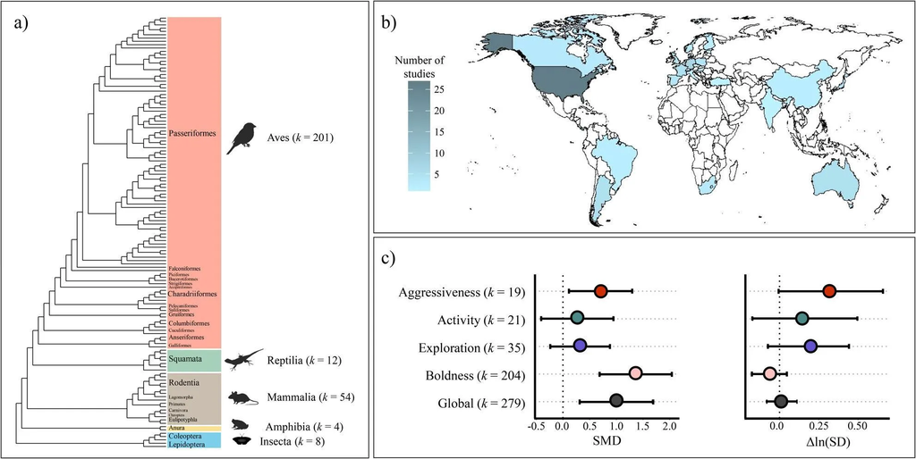

##### 📄 Selecting among counterfactual methods to evaluate conservation interventions ✨ AI title

Shared by **Pablo Garcia-Diaz** [@pablo-ecology.bsky.social](https://bsky.app/profile/pablo-ecology.bsky.social) · 2026-05-26 · 💚 5 likes on Bluesky

```
<div class='tag-row'><span class='tag tag-methods'>methods</span></div>
{% raw %}Selecting among counterfactual methods to evaluate conservation interventions 🌎🌐🧪 @conservationsp.bsky.social{% endraw %}
```

**link:** https://conbio.onlinelibrary.wiley.com/doi/full/10.1111/csp2.70066  
[View Original Post on Bluesky](https://bsky.app/profile/did:plc:jvl2oy4s2hpizxkbd7ngq7ty/post/3mmrkpqk7ns2e)↑ Up

[output not shown]

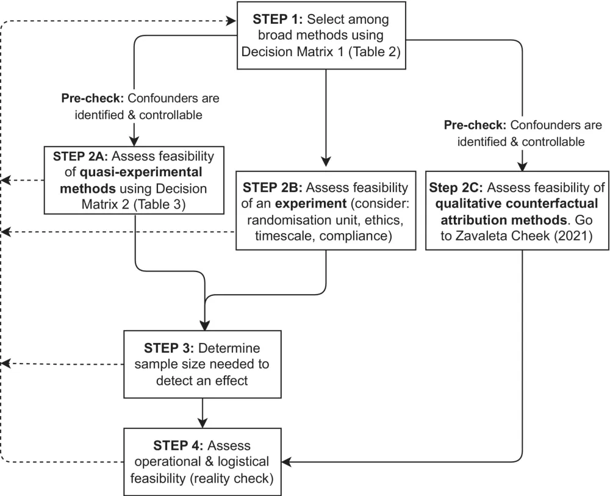

##### 📄 Precision ecology for targeted conservation action

Shared by **James Bullock** [@jmbecologist.bsky.social](https://bsky.app/profile/jmbecologist.bsky.social) · 2026-05-26 · 💚 26 likes on Bluesky

```
<div class='tag-row'><span class='tag tag-methods'>methods</span></div>
{% raw %}Evidence-based approaches to conservation have 2 problems 1) Generalised evidence doesn’t take account of context 2) Specific information isn’t transferable Precision Ecology addresses these problems And we’re now starting a grant to test PE & provide guidance!{% endraw %}
```

**link:** https://www.nature.com/articles/s41559-025-02733-4  
[View Original Post on Bluesky](https://bsky.app/profile/did:plc:n5f6mgg4yicla5z3e2blr3kz/post/3mmrjsgtxhk2w)↑ Up

[output not shown]

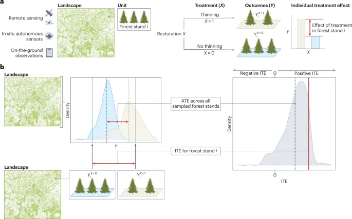

##### 📄 The value of qualitative approaches to impact evaluation in biodiversity conservation ✨ AI title

Shared by **Pablo Garcia-Diaz** [@pablo-ecology.bsky.social](https://bsky.app/profile/pablo-ecology.bsky.social) · 2026-05-26 · 💚 6 likes on Bluesky

```
<div class='tag-row'><span class='tag tag-policy'>policy</span><span class='tag tag-methods'>methods</span></div>
{% raw %}The value of qualitative approaches to impact evaluation in biodiversity conservation 🌎🌐🧪{% endraw %}
```

**link:** https://conbio.onlinelibrary.wiley.com/doi/10.1111/csp2.70102  
[View Original Post on Bluesky](https://bsky.app/profile/did:plc:jvl2oy4s2hpizxkbd7ngq7ty/post/3mmrija27fs2r)↑ Up

[output not shown]

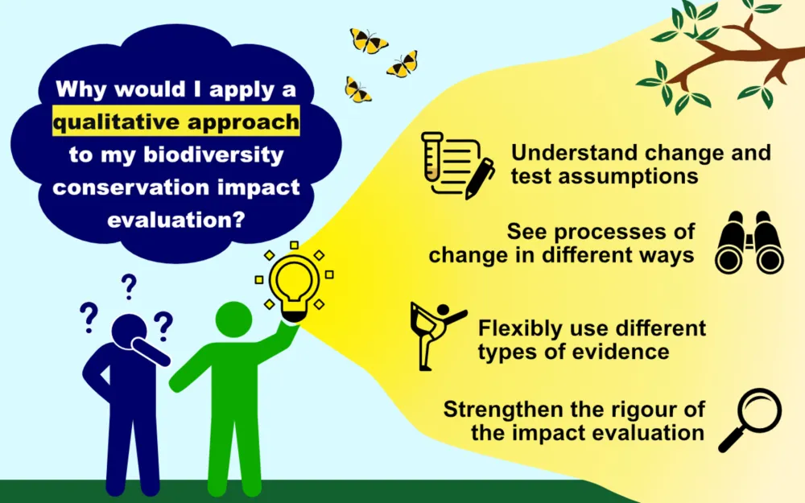

##### 📄 Accounting for human–nature linkages in area-based conservation monitoring through social–ecological indicator bundles ✨ AI title

Shared by **Pablo Garcia-Diaz** [@pablo-ecology.bsky.social](https://bsky.app/profile/pablo-ecology.bsky.social) · 2026-05-26 · 💚 2 likes on Bluesky

```
<div class='tag-row'><span class='tag tag-ecosystem-services'>ecosystem-services</span><span class='tag tag-policy'>policy</span><span class='tag tag-methods'>methods</span></div>
{% raw %}Accounting for human–nature linkages in area-based conservation monitoring through social–ecological indicator bundles 🌎🌐🧪{% endraw %}
```

**link:** https://conbio.onlinelibrary.wiley.com/doi/10.1111/cobi.70156  
[View Original Post on Bluesky](https://bsky.app/profile/did:plc:jvl2oy4s2hpizxkbd7ngq7ty/post/3mmre6qqpx225)↑ Up

[output not shown]

[figure not shown]

##### 📄 Rewilding: ten years of evolution and development ✨ AI title

Shared by **Pablo Garcia-Diaz** [@pablo-ecology.bsky.social](https://bsky.app/profile/pablo-ecology.bsky.social) · 2026-05-26 · 💚 17 likes on Bluesky

```
<div class='tag-row'><span class='tag tag-policy'>policy</span></div>
{% raw %}Rewilding: Ten Years of Evolution and Development 🌎🌐🧪{% endraw %}
```

**link:** https://www.annualreviews.org/content/journals/10.1146/annurev-environ-111523-102359  
[View Original Post on Bluesky](https://bsky.app/profile/did:plc:jvl2oy4s2hpizxkbd7ngq7ty/post/3mmr5c7fobc2j)↑ Up

[output not shown]

[figure not shown]

##### 📄 Amazon climate corridors in Peru critical for tropical biodiversity survival ✨ AI title

Shared by **ForestPlots** [@forestplots.bsky.social](https://bsky.app/profile/forestplots.bsky.social) · 2026-05-26 · 💚 10 likes on Bluesky

```
<div class='tag-row'><span class='tag tag-tropical-forest'>tropical-forest</span><span class='tag tag-climate'>climate</span><span class='tag tag-macroecology'>macroecology</span><span class='tag tag-policy'>policy</span></div>
{% raw %}Is Peru the most important nation on Earth for the future of tropical life? To escape increasing heat and drought, the Amazon needs big, protected ecosystem corridors. This new study shows where they need to be.{% endraw %}
```

**link:** https://www.sciencedirect.com/science/article/pii/S2351989426001836?via%3Dihub&fbclid=IwY2xjawSCZEtleHRuA2FlbQIxMABzcnRjBmFwcF9pZBAyMjIwMzkxNzg4MjAwODkyAAEeD5u1Y6dUUsfKs_gTrcbbF0nAl018RTL-3sDPb0EPW1SFu9MKmxLdTASTNXo_aem_sBQT1dD1hALbCPDXoa402A  
[View Original Post on Bluesky](https://bsky.app/profile/did:plc:neh6ptepenqtxvdxkeu5twct/post/3mmqvo7ioek2a)↑ Up

[output not shown]

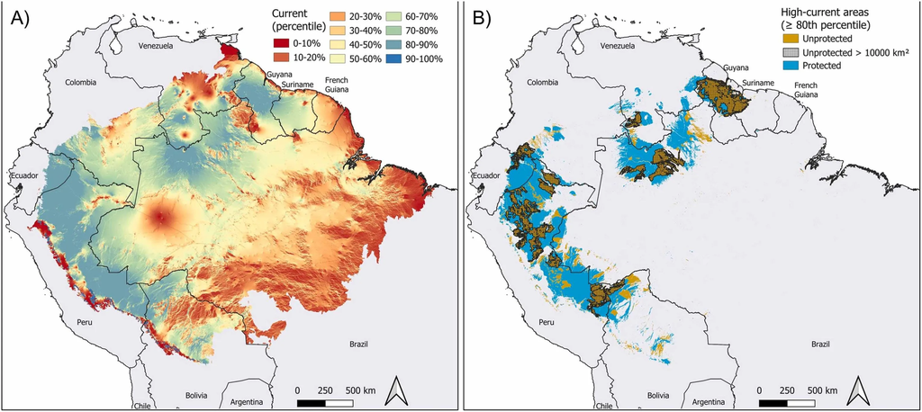

##### 📄 Webinar: Eco-evolutionary modelling seminar featuring Korinna Allhoff ✨ AI title

Shared by **Institut Natura e Teoria ※ Pireneus (INTP)** [@intp-science.bsky.social](https://bsky.app/profile/intp-science.bsky.social) · 2026-05-26 · 💚 6 likes on Bluesky

[output not shown]

**link:** https://eco-evolutionary-modelling.uni-hohenheim.de/en/english  
[View Original Post on Bluesky](https://bsky.app/profile/did:plc:ojhu5hugdadurowr4wsqrv47/post/3mmqqpb63zk2c)↑ Up

[output not shown]

[figure not shown]

##### 📄 Habitat fragmentation can either increase or decrease with habitat loss

Shared by **Federico Riva** [@rivaecology.bsky.social](https://bsky.app/profile/rivaecology.bsky.social) · 2026-05-25 · 💚 6 likes on Bluesky

```
<div class='tag-row'><span class='tag tag-macroecology'>macroecology</span></div>
{% raw %}Habitat fragmentation can either increase or decrease with habitat loss{% endraw %}
```

**link:** https://link.springer.com/article/10.1007/s10980-026-02345-8  
[View Original Post on Bluesky](https://bsky.app/profile/did:plc:4lh72xky3wwxw2v74k7upkr6/post/3mmpautibak26)↑ Up

[output not shown]

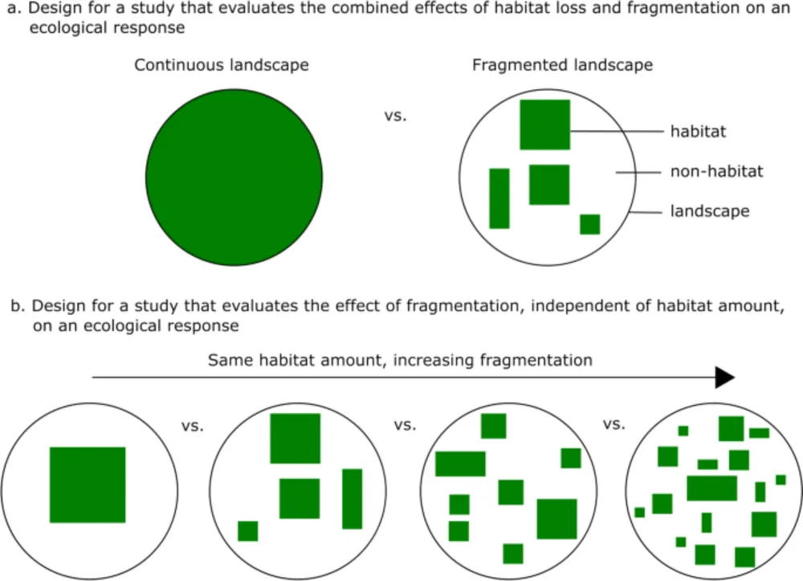

##### 📄 Species age shapes niche position and specialization in Neotropical vertebrates ✨ AI title

Shared by **Carlos Calderón del Cid** [@caldecid.bsky.social](https://bsky.app/profile/caldecid.bsky.social) · 2026-05-25 · 💚 14 likes on Bluesky

```
<div class='tag-row'><span class='tag tag-macroecology'>macroecology</span><span class='tag tag-traits'>traits</span></div>
{% raw %}How does species age influence niche position and specialization across the Neotropics? In a new study published in @ecography.bsky.social with @bruvilela.bsky.social, @fabrovillalobos.bsky.social , and R Dobrovolski:{% endraw %}
```

**link:** https://doi.org/10.1002/ecog.08192  
[View Original Post on Bluesky](https://bsky.app/profile/did:plc:unmx7nfnjbowe7zxqwsdmpu2/post/3mmosf37lqk2y)↑ Up

[output not shown]

[figure not shown]

##### 📄 Utilizing aquatic environmental DNA to address global biodiversity targets

Shared by **Florian Altermatt** [@florianaltermatt.bsky.social](https://bsky.app/profile/florianaltermatt.bsky.social) · 2026-05-25 · 💚 6 likes on Bluesky

```
<div class='tag-row'><span class='tag tag-freshwater'>freshwater</span><span class='tag tag-policy'>policy</span></div>
{% raw %}A year ago we published our perspective "Utilizing aquatic environmental DNA 🧬 to address global 🌍 🌐 biodiversity 🦐 🐟 🦠 targets 🎯 " in Nature Reviews Biodiversity: 1/10🧵{% endraw %}
```

**link:** https://www.nature.com/articles/s44358-025-00044-x  
[View Original Post on Bluesky](https://bsky.app/profile/did:plc:ydzmya3tppgd3h2udjzu4iph/post/3mmoilvc2jk2y)↑ Up

[output not shown]

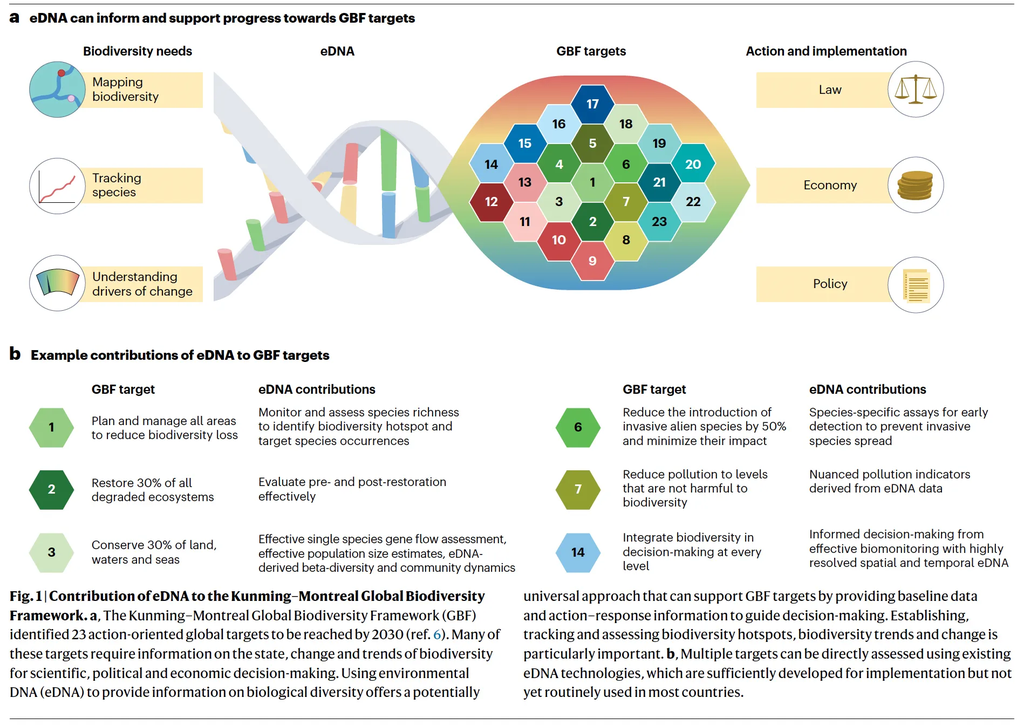

##### 📄 Mass flowering of the seagrass Posidonia oceanica after 2022 record-breaking marine heatwaves, a Pan-Mediterranean study

Shared by **Jérémy Carlot** [@jerem-carlot.bsky.social](https://bsky.app/profile/jerem-carlot.bsky.social) · 2026-05-25 · 💚 18 likes on Bluesky

```
<div class='tag-row'><span class='tag tag-coastal'>coastal</span><span class='tag tag-climate'>climate</span><span class='tag tag-macroecology'>macroecology</span></div>
{% raw %}Our study is now out in @commsearth.nature.com. 2022 heatwaves triggered a record mass flowering of Mediterranean Posidonia oceanica. 🌊 A sign of resilience or a red flag for ocean health? The answer here: Study led by Patrick Austruch 🌱 🌐{% endraw %}
```

**link:** https://doi.org/10.1038/s43247-026-03631-8  
[View Original Post on Bluesky](https://bsky.app/profile/did:plc:geytktsrkn74y3b6lpwszt66/post/3mmogrfiwjc2d)↑ Up

[output not shown]

[figure not shown]

##### 📄 The fate of mountain biodiversity in a warming world

Shared by **Nature Reviews Biodiversity** [@natrevbiodiv.nature.com](https://bsky.app/profile/natrevbiodiv.nature.com) · 2026-05-25 · 💚 10 likes on Bluesky

```
<div class='tag-row'><span class='tag tag-climate'>climate</span><span class='tag tag-macroecology'>macroecology</span></div>
{% raw %}New online! The fate of mountain biodiversity in a warming world{% endraw %}
```

**link:** http://dlvr.it/TSj6dQ  
[View Original Post on Bluesky](https://bsky.app/profile/did:plc:y3v4l27oii2ecfrit6h6s6oy/post/3mmno7naypv2t)↑ Up

[output not shown]

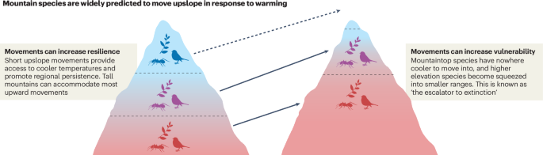

##### 📄 Hierarchical Spatial Data Subdivision into Topologically Contiguous Units [R package hespdiv version 1.2.10]

Shared by **Andrej Spiridonov** [@andrejpaleo.bsky.social](https://bsky.app/profile/andrejpaleo.bsky.social) · 2026-05-24 · 💚 16 likes on Bluesky

```
<div class='tag-row'><span class='tag tag-methods'>methods</span><span class='tag tag-macroecology'>macroecology</span><span class='tag tag-data'>data</span></div>
{% raw %}The R package 'hespdiv' is now in the CRAN! 🥳 Now automatic hierarchical and statistically testable contiguous bioregionalization is available for everyone! Bretskyan_hiearchy 🧪⚒️ EvoBio Paleobio Geology Biogeography Macroecology{% endraw %}
```

**link:** https://cran.rstudio.com/web/packages/hespdiv/index.html  
[View Original Post on Bluesky](https://bsky.app/profile/did:plc:qb6x3o2dt7vkteqeqrqpjtxc/post/3mmmq6rpp4c2p)↑ Up

[output not shown]

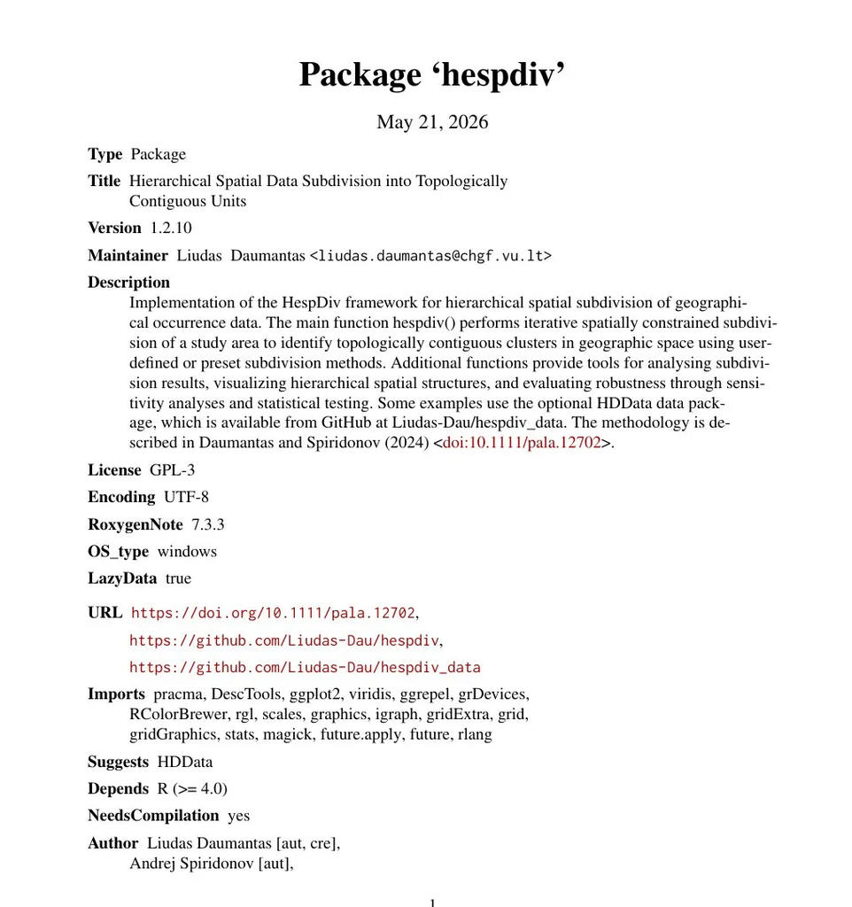

##### 📄 A beautiful birthday

Shared by **Jonas Lembrechts** [@jlembrechts.bsky.social](https://bsky.app/profile/jlembrechts.bsky.social) · 2026-05-24 · 💚 13 likes on Bluesky

```
<div class='tag-row'><span class='tag tag-alpine-mountain'>alpine-mountain</span><span class='tag tag-networks'>networks</span></div>
{% raw %}The Mountain Invasion Research Network (MIREN) just turned 20! 🎉 We celebrate with a new paper in Biol Invasions on what 20 years of mountain monitoring taught us - and how ecological networks can survive (and thrive). Blog: Paper:{% endraw %}
```

**link:** https://the3dlab.org/2026/05/24/a-beautiful-birthday/  
[View Original Post on Bluesky](https://bsky.app/profile/did:plc:3fbqr6o45njrwteegpbwuzir/post/3mmmokkjq6s2u)↑ Up

[output not shown]

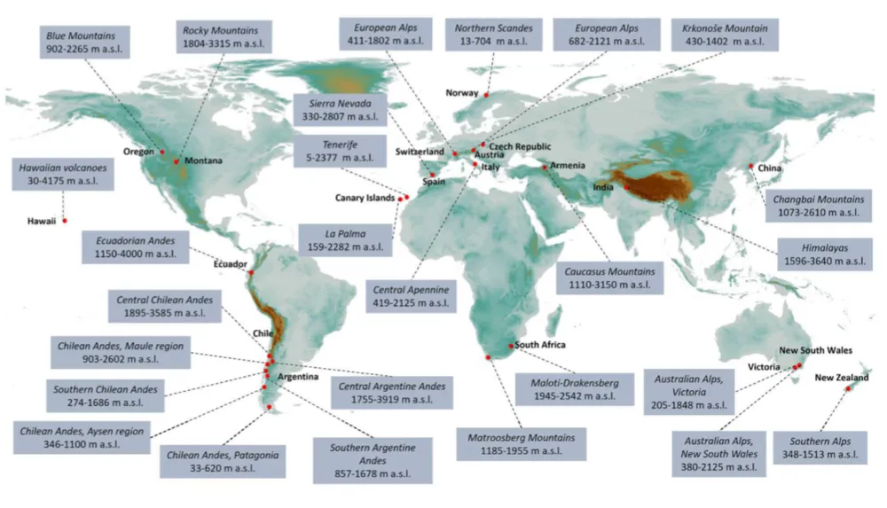

##### 📄 WEBINAR: Leading the global response to biological invasions: A dialogue between OneSTOP & GuardIAS

Shared by **Stelios Katsanevakis** [@skatsanevakis.bsky.social](https://bsky.app/profile/skatsanevakis.bsky.social) · 2026-05-24 · 💚 2 likes on Bluesky

[output not shown]

**link:** https://youtu.be/bC1DOp5Wt2o  
[View Original Post on Bluesky](https://bsky.app/profile/did:plc:7fpeunfp74zwh6keq63zmdgt/post/3mmmjf46oz22s)↑ Up

[output not shown]

[figure not shown]

##### 📄 Plant strategy distributions in European grasslands under climate change ✨ AI title

Shared by **Milan Chytrý** [@milanchytry.bsky.social](https://bsky.app/profile/milanchytry.bsky.social) · 2026-05-24 · 💚 17 likes on Bluesky

```
<div class='tag-row'><span class='tag tag-traits'>traits</span><span class='tag tag-climate'>climate</span><span class='tag tag-macroecology'>macroecology</span></div>
{% raw %}Our new study, led by Xiao-Peng Tan, maps the distribution of plant strategies across European grasslands and projects how current patterns will be affected by ongoing climate change. Open-access article: @ecography.bsky.social{% endraw %}
```

**link:** https://doi.org/10.1002/ecog.08334  
[View Original Post on Bluesky](https://bsky.app/profile/did:plc:hm2e3dgvcx4jjk5iqcriel3v/post/3mmlvbojdoc2c)↑ Up

[output not shown]

[figure not shown]

##### 📄 Invasive seaweeds may functionally compensate for endemic species loss in the warming Mediterranean Sea ✨ AI title

Shared by **Annals of Botany** [@annbot.bsky.social](https://bsky.app/profile/annbot.bsky.social) · 2026-05-24 · 💚 2 likes on Bluesky

```
<div class='tag-row'><span class='tag tag-coastal'>coastal</span><span class='tag tag-climate'>climate</span><span class='tag tag-traits'>traits</span></div>
{% raw %}🔥ADVANCE ACCESS🔥: Invasive seaweeds may functionally compensate for the expected loss of endemic temperate species in the fast-warming Mediterranean Sea PlantScience{% endraw %}
```

**link:** https://doi.org/10.1093/aob/mcag105  
[View Original Post on Bluesky](https://bsky.app/profile/did:plc:qowz7hsvbml54nxg6hzo7rrg/post/3mmlt73atr32w)↑ Up

[output not shown]

[figure not shown]

##### 📄 Antarctic Treaty System needs a disaster management authority for the continent ✨ AI title

Shared by **Proceedings of the National Academy of Sciences** [@pnas.org](https://bsky.app/profile/pnas.org) · 2026-05-23 · 💚 6 likes on Bluesky

```
<div class='tag-row'><span class='tag tag-policy'>policy</span><span class='tag tag-climate'>climate</span></div>
{% raw %}Opinion: Antarctica and the scientists working there aren’t prepared for disasters on the remote continent. The AntarcticTreatySystem needs a disaster management authority to address biological & physical threats. https://ow.ly/NySP50Z3fZE biosecurity ClimateChange{% endraw %}
```

**link:** https://ow.ly/NySP50Z3fZE  
[View Original Post on Bluesky](https://bsky.app/profile/did:plc:cvhduyk4ukre2drmboh2z3mi/post/3mmjweuzmbi2t)↑ Up

[output not shown]

[figure not shown]

##### 📄 Metawebs as an ecological modeling framework in macroecology and biogeography ✨ AI title

Shared by **Vinicius Bastazini** [@vinibastazini.bsky.social](https://bsky.app/profile/vinibastazini.bsky.social) · 2026-05-23 · 💚 19 likes on Bluesky

```
<div class='tag-row'><span class='tag tag-macroecology'>macroecology</span></div>
{% raw %}Our new study synthesizes the role of metawebs as an ecological modeling framework in macroecology and biogeography, outlining their applications, limitations, and future directions. 🧪🦤🌎🌐 biodiversity ecology NetSci conservation ecologicalnetworks{% endraw %}
```

**link:** https://www.sciencedirect.com/science/article/pii/S0304380026002024?via%3Dihub  
[View Original Post on Bluesky](https://bsky.app/profile/did:plc:vb4z72agepotbk4sbdl5dfrd/post/3mmju72ymus2p)↑ Up

[output not shown]

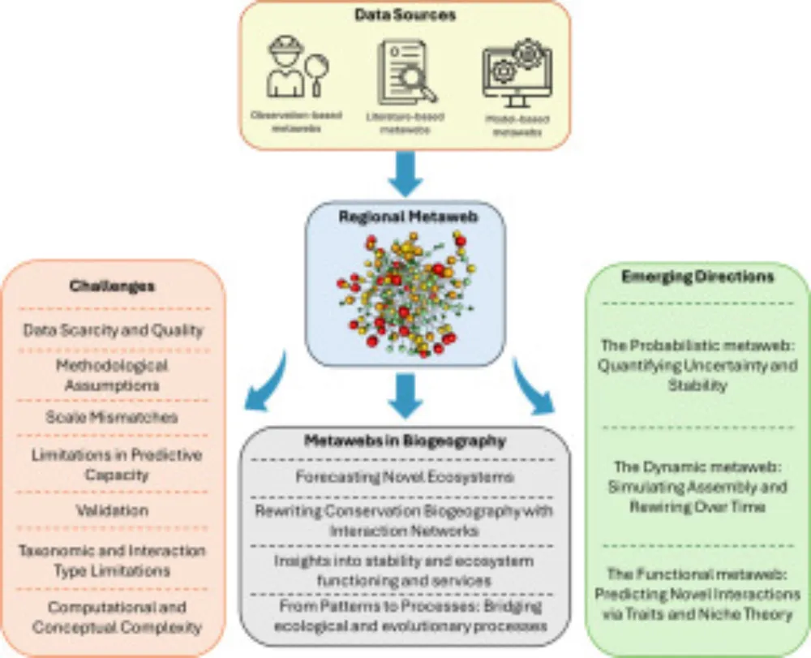

##### 📄 A practical guide to species trend detection using Frescalo local frequency scaling ✨ AI title

Shared by **Pablo Garcia-Diaz** [@pablo-ecology.bsky.social](https://bsky.app/profile/pablo-ecology.bsky.social) · 2026-05-22 · 💚 6 likes on Bluesky

```
<div class='tag-row'><span class='tag tag-methods'>methods</span><span class='tag tag-macroecology'>macroecology</span></div>
{% raw %}A practical guide to species trend detection with unstructured data using local frequency scaling (Frescalo) 🌐🌎🧪{% endraw %}
```

**link:** https://nsojournals.onlinelibrary.wiley.com/doi/10.1002/ecog.08270  
[View Original Post on Bluesky](https://bsky.app/profile/did:plc:jvl2oy4s2hpizxkbd7ngq7ty/post/3mmh7mqexq222)↑ Up

[output not shown]

[figure not shown]

##### 📄 Greater tree diversity lowers soil carbon temperature sensitivity via microbial stabilization mechanisms ✨ AI title

Shared by **Journal of Ecology** [@journalofecology.bsky.social](https://bsky.app/profile/journalofecology.bsky.social) · 2026-05-22 · 💚 15 likes on Bluesky

[output not shown]

**link:** https://buff.ly/DcNVNNW  
[View Original Post on Bluesky](https://bsky.app/profile/did:plc:wkytvpjriqhr7q54cr4wqk7t/post/3mmh3w4sd2223)↑ Up

[output not shown]

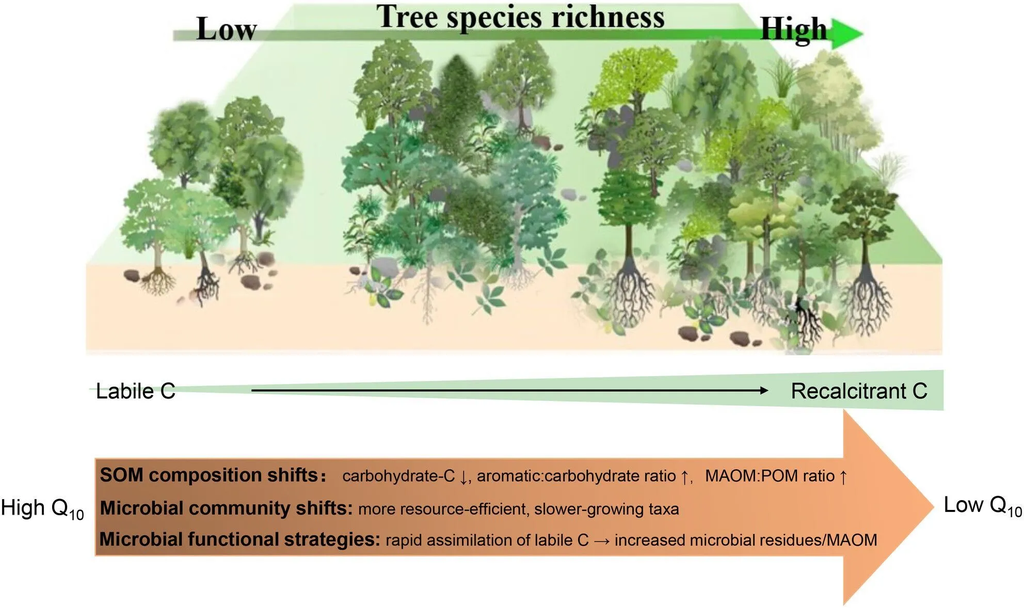

##### 📄 Comprehensive evolutionary phylogeny of global bumblebee species integrating nuclear, mitochondrial, and genomic data ✨ AI title

Shared by **Paul Williams** [@paulwilliamsnhm.bsky.social](https://bsky.app/profile/paulwilliamsnhm.bsky.social) · 2026-05-22 · 💚 38 likes on Bluesky

```
<div class='tag-row'><span class='tag tag-macroecology'>macroecology</span></div>
{% raw %}New evolutionary tree for all of the world's bumblebee species, from (1) slow-evolving nuclear genes, (2) fast-evolving mitochondrial genes, and (3) results from genomic data, to provide a complete starting point for comparative studies of all bumblebees{% endraw %}
```

**link:** https://www.researchgate.net/publication/405148391_Evolutionary_Tree_for_All_Bumblebee_Species_World-Wide_Estimated_by_Combining_Information_from_Fast-Evolving_Genes_Slow-Evolving_Genes_and_Genomic_Data_Apidae_Bombus  
[View Original Post on Bluesky](https://bsky.app/profile/did:plc:rp5kuopusr2duaiy6ifrjaua/post/3mmgz5vg6ds2h)↑ Up

[output not shown]

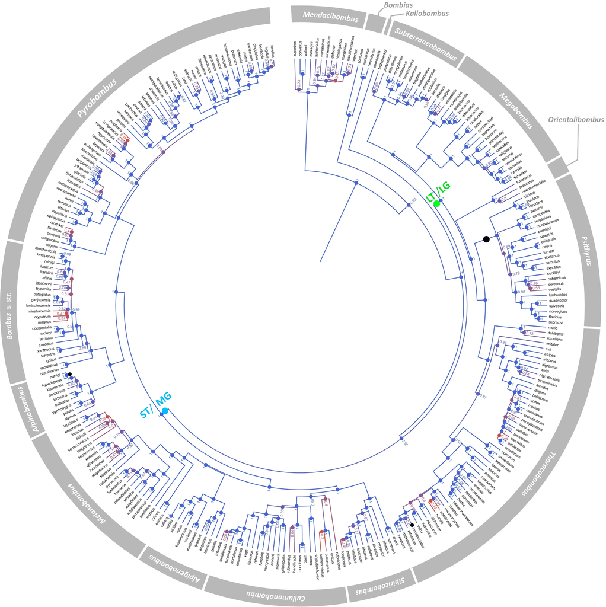

##### 📄 Urban animals are bolder than rural counterparts across a global meta-analysis of vertebrates and insects ✨ AI title

Shared by **British Ecological Society** [@britishecologicalsociety.org](https://bsky.app/profile/britishecologicalsociety.org) · 2026-05-22 · 💚 51 likes on Bluesky

```
<div class='tag-row'><span class='tag tag-birds'>birds</span><span class='tag tag-traits'>traits</span></div>
{% raw %}Across birds, mammals, amphibians, reptiles and insects - urban animals are consistently bolder than their rural counterparts, according to a new global meta-analysis. 🌍🧪{% endraw %}
```

**link:** https://f.mtr.cool/haqoinsfmd  
[View Original Post on Bluesky](https://bsky.app/profile/did:plc:3omgpdswrobmlqbq6q6pcmft/post/3mmgomlwnx42h)↑ Up

[output not shown]

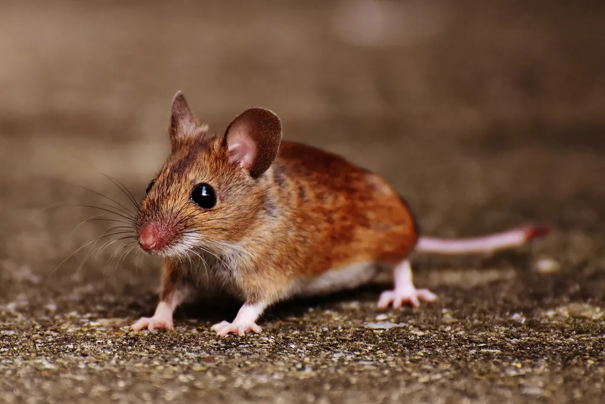

##### 📄 Frontiers | Reviews in Marine Ecosystem Ecology: 2026

Shared by **Stelios Katsanevakis** [@skatsanevakis.bsky.social](https://bsky.app/profile/skatsanevakis.bsky.social) · 2026-05-21 · 💚 8 likes on Bluesky

```
<div class='tag-row'><span class='tag tag-marine'>marine</span><span class='tag tag-synthesis'>synthesis</span></div>
{% raw %}Excited to co-edit the Research Topic “Reviews in Marine Ecosystem Ecology: 2026” in Frontiers in Marine Science! We invite high-quality review papers on MarineBiodiversity, ecosystem functioning, advances in monitoring, CumulativeImpacts & more. 👉 🌊🐟🪸🌐🌍{% endraw %}
```

**link:** https://www.frontiersin.org/research-topics/80087/reviews-in-marine-ecosystem-ecology-2026  
[View Original Post on Bluesky](https://bsky.app/profile/did:plc:7fpeunfp74zwh6keq63zmdgt/post/3mmf5g5bo6k25)↑ Up

[output not shown]

[figure not shown]